# Intro Session 1: Motivating reproducibility

This RMarkdown file contains R code you can use to complete the exercises from Intro Session 1. To see the output simply click on Knit HTML above. This might prompt you to install and load some required packages, specifically `knitr`. Just click yes, and the a document including this narrative, the R code, and figures should pop up.

## Data:

The `read.csv` function is used to read the data into R. Note that the argument provided for this function is the complete path that leads to the dataset from your current working directory (where this RMarkdown file is located). Also note that this is provided as a character string, hence in quotation marks.

```r
gap_5060 = read.csv("data/gapminder-5060.csv")
```

## Packages:

We will use the `ggplot2` package to make the plots for these exercises. This is not the only way to make this plot, but the `ggplot2` package has some aesthetic defaults that makes it attractive.

At this point you should have downloaded this package using the `install.packages` function.

Now we need to explicitly load the package:

```r
library("ggplot2")
```

If you’d like to learn more about `ggplot2`, visit http://ggplot2.org/, which includes links to documentation about the functions in this package as well as external resources.

## Task 1:

**Goal:** Visualize the relationship between life expectancy over time for Canada in the 1950s and 1960s using a line plot.

- Create a subset of `gap_5060` for Canada:

The first argument is the dataset, and the second argument is the logical expression that you want to use for subsetting. Note that the “double equals” in R, `==`, reads as “if it is equal to”.

```r
ca_5060 = subset(gap_5060, country == "Canada")
```

Each function in R comes with a help file. To view the help file for subset you can either click on the *Help* tab in the lower right pane, and enter the function’s name in the search box, or type `?subset` in the *Console*.

- Create the plot:

In the first layer we specify the dataset and the variables to go in the x and y axes, and next we layer on the lines.

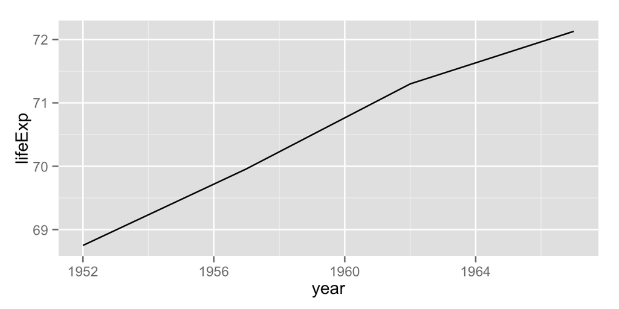

```r
ggplot(data = ca_5060, aes(x = year, y = lifeExp)) + # creates the first layer
  geom_line()                                        # add line
```

### Task 1 - Stretch goal:

**Goal:** Add lines for Mexico and US in the 1950s and 1960s.

- Create a subset of `gap_5060` for Canada, Mexico, and US:

First we create a vector of the countries we want:

```r
countries = c("Canada", "Mexico", "United States")
```

Then we subset for observations where the country is in the list of countries we defined above:

```r
northamer_5060 = subset(gap_5060, country %in% countries)
```

- Create the plot:

The only difference in the code below is `colour = country`, since we want a different color for each country.

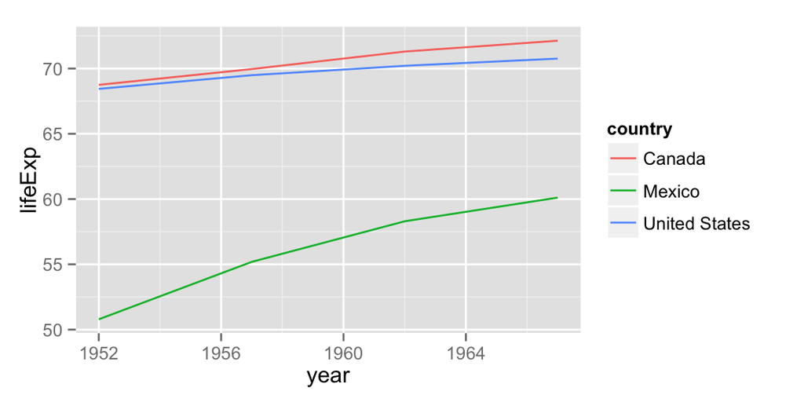

```r
ggplot(data = northamer_5060,
       aes(x = year, y = lifeExp, colour = country)) + # add colour by country
  geom_line()                                          # add line
```

## Task 2:

**Goal:** Visualize the relationship between GDP and life expectancy for countries in Europe in 1952 using a scatter plot.

- Create a subset of `gap_5060` for Europe in 1952:

```r
eu_52 = subset(gap_5060, continent == "Europe" & gap_5060$year == 1952)
```

- Create the plot:

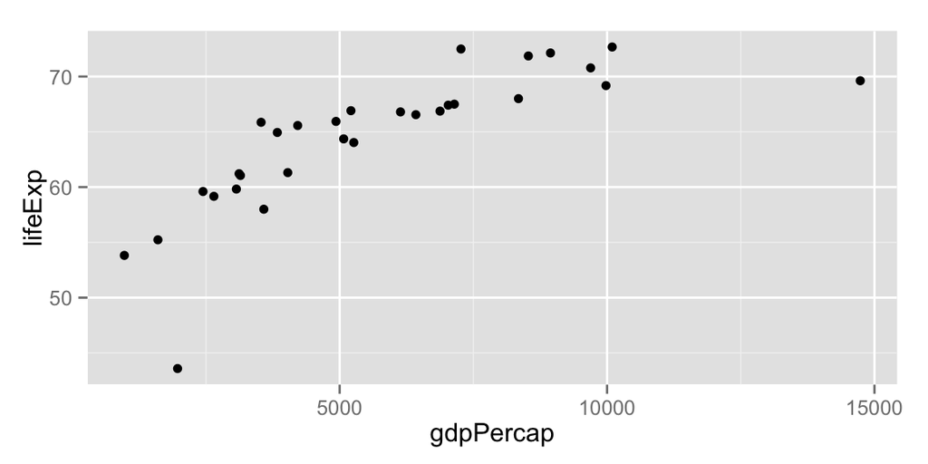

```r
ggplot(data = eu_52, aes(x = gdpPercap, y = lifeExp)) +
  geom_point()                                          # add points
```

### Task 2 - Stretch goal:

**Goal:** Add year 1967 in another color.

- Create a subset of `gap_5060` for Europe in 1952 and 1967:

```r
years = c(1952, 1967)
eu_5267 = subset(gap_5060, continent == "Europe" & (year %in% years))
```

- Create the plot:

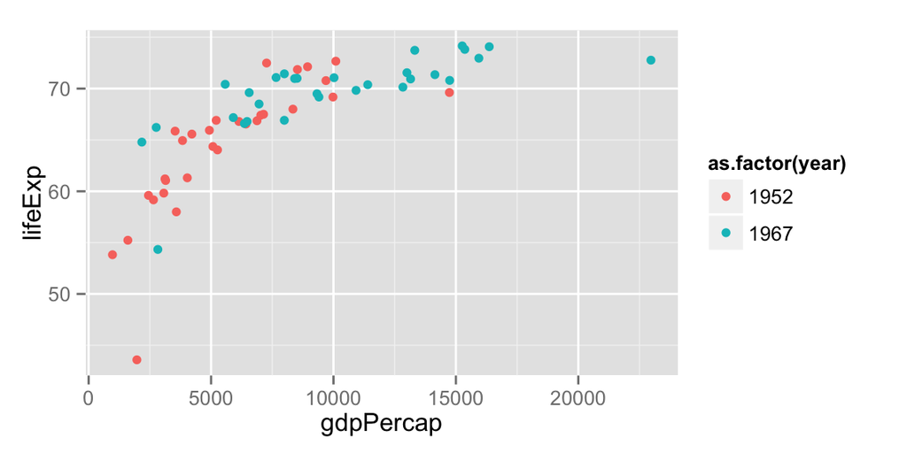

```r
ggplot(data = eu_5267, aes(x = gdpPercap, y = lifeExp, colour = as.factor(year))) +
  geom_point()
```